# Q1 Report: Upper-Div PSTAT Course Count and Statistics Comfort Correlation

## Summary

We asked this question: **Is the number of upper-division PSTAT courses a student has taken associated with their self-reported comfort level in statistics?**

In this sample of 51 students, we found no statistically significant association. Mean comfort stayed near 4 for the groups with enough students to compare, and three different statistical approaches (ordinal logistic regression, ordinal GAM, and Spearman rank correlation) all fail to find a relationship distinguishable from zero. The sample is small, and several course-count groups contain only one or two students, so the results are better interpreted as “no clear pattern” than as “no relationship exists.”

## Data and Sample

The analysis uses 51 students, each with a count of Upper Division PSTAT courses taken (`n_ud_pstat`) and a self-reported statistics comfort rating (`stat_comfort`).

- **Comfort ratings are concentrated at the high end.** Only ratings 3, 4 and 5 appear: 9 students rated 3, 26 rated 4, and 16 rated 5. Nobody rated 1 or 2. Overall, 82% of students (42 of 51) reported 4 or 5, and the mean rating is about 4.1.
- **Course counts range from 2 to 10 but are bunched in the middle.** The most common count is 5 (18 students), followed by 6 (11) and 7 (8). Groups of 4 to 7 courses together hold 43 of the 51 students (84%).
- **Five of the nine course-count groups have fewer than 5 students.** Counts of 2, 3, 8, 9 and 10 courses contain 1, 1, 2, 2 and 2 students respectively, so 8 students in total sit in groups too small to say much about.

Because nobody reported low comfort, the outcome has little room to vary. This restricted range makes any association harder to detect.

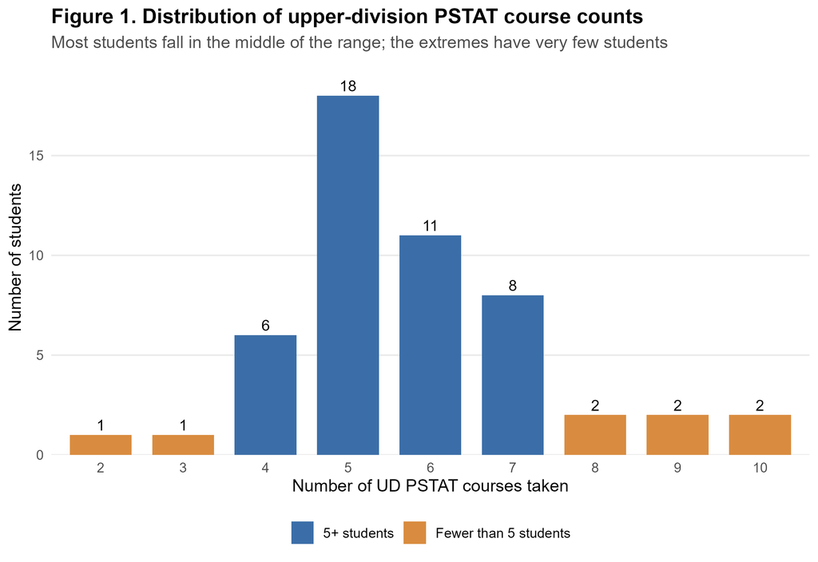

Figure 1. Distribution of upper-division PSTAT course counts.

## Descriptive Results

| UD PSTAT courses | Students | Mean comfort | % rating 4 or 5 |
| --- | --- | --- | --- |
| 2 | 1 | 5.00 | 100% |
| 3 | 1 | 5.00 | 100% |
| 4 | 6 | 4.00 | 66.7% |
| 5 | 18 | 4.22 | 94.4% |
| 6 | 11 | 4.00 | 72.7% |
| 7 | 8 | 4.00 | 87.5% |
| 8 | 2 | 3.50 | 50% |
| 9 | 2 | 4.00 | 50% |
| 10 | 2 | 5.00 | 100% |

**Groups with enough students (4 to 7 courses).** Mean comfort is essentially flat: 4.00, 4.22, 4.00 and 4.00. The share reporting 4 or 5 bounces between 67% and 94% without trending in either direction. The group of 5 courses has the highest share (94%), but the groups on either side of it do not continue that pattern, so it looks like ordinary sampling variation rather than a trend.

**Small groups (2, 3, 8, 9 and 10 courses).** These groups produce the most extreme-looking values (means of 5.00 at 2, 3 and 10 courses, and 3.50 at 8 courses). With one or two students each, a single response moves the mean by a full point or more. These values should not be read as evidence of a pattern. The apparent U-shape that appears when they are plotted together (high, then lower in the middle, then high again) is exactly what we would expect from a handful of unstable groups at the edges of a flat relationship.

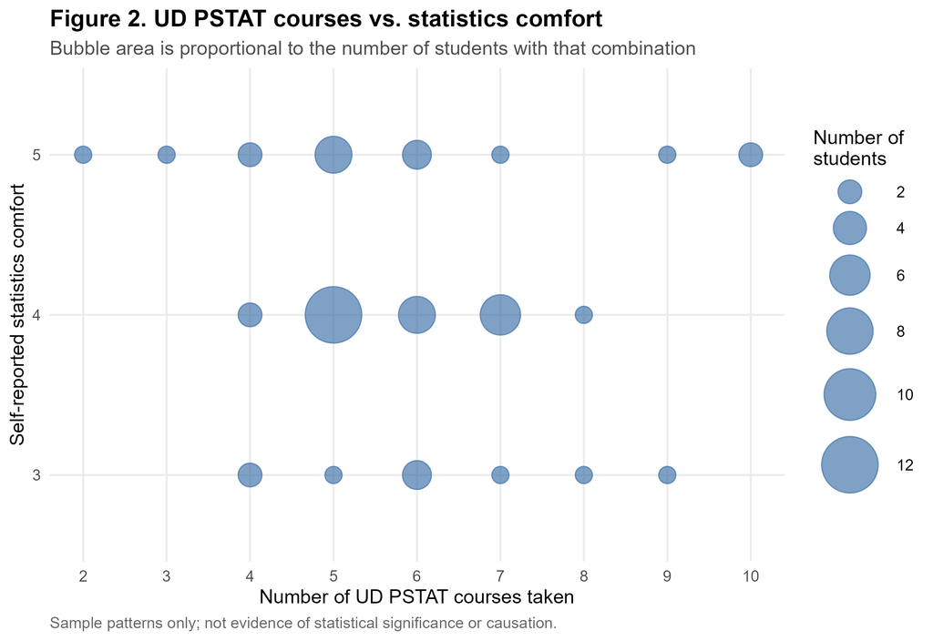

Figure 2. UD PSTAT courses vs. statistics comfort (bubble area = number of students).

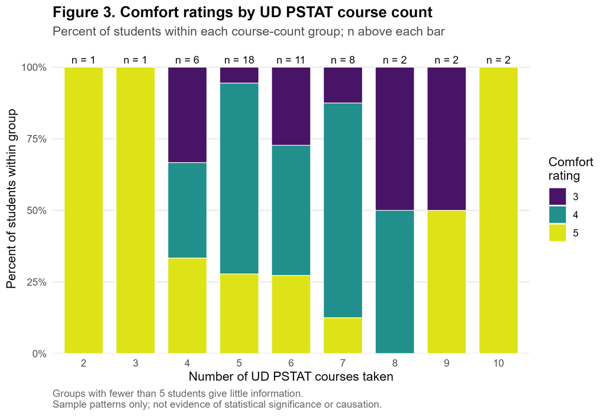

Figure 3. Comfort ratings by UD PSTAT course count (percent within group, n above each bar).

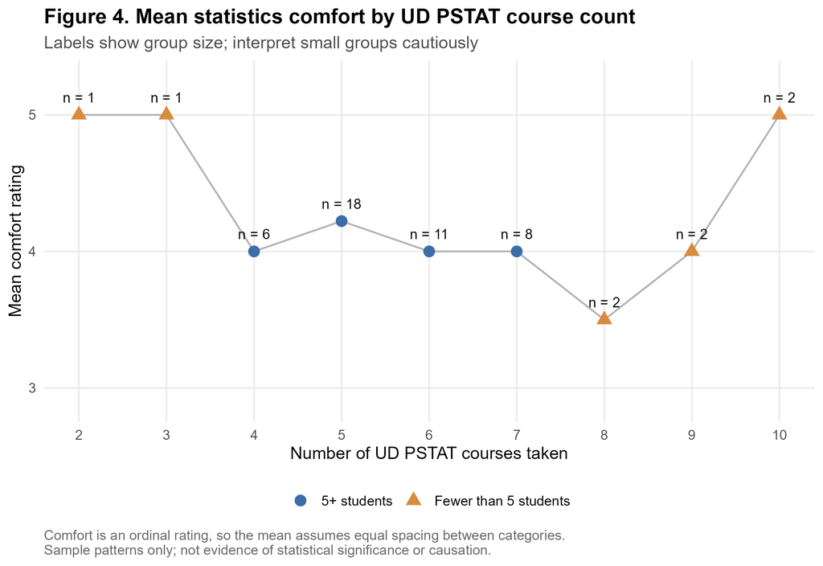

Figure 4. Mean statistics comfort by UD PSTAT course count.

## Model Results

| Method | What it assumes | Key result | Interpretation |
| --- | --- | --- | --- |
| Ordinal logistic regression | Each additional course shifts the odds of higher comfort by a constant amount | Odds ratio 0.92 per course, p = 0.65 | No evidence of an association |
| Ordinal GAM (k = 3) | A flexible, possibly non-linear relationship | Smooth term p = 0.11; 5.6% deviance explained | Not significant at the usual 0.05 level; weak fit |
| Spearman rank correlation | A monotonic (consistently rising or falling) relationship | rho = -0.11, p = 0.45 | Essentially no monotonic association |

**Ordinal logistic regression.** The odds ratio is 0.92 per additional UD PSTAT course. An odds ratio of 1 means no effect, so 0.92 leans very slightly negative, but the p-value of 0.65 means this is well within what chance alone would produce. The predicted probabilities for ratings 3, 4 and 5 change very little between 2 and 10 courses, and their confidence bands are wide enough to include almost any modest trend in either direction (Figure 5).

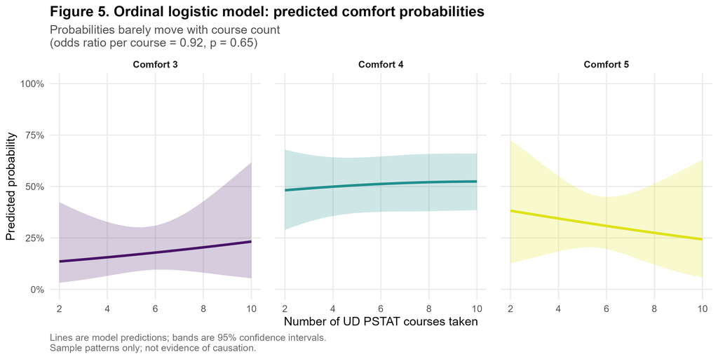

Figure 5. Ordinal logistic model: predicted comfort probabilities.

**Ordinal GAM.** Allowing a non-linear relationship fits slightly better than the straight-line model, and the fitted curve is U-shaped (Figures 6 and 7). However, the smooth term is not significant (p = 0.11), the model explains only 5.6% of the deviance, and the 95% confidence band on the smooth effect includes or just touches zero throughout. The curve is steepest at the extremes, where the data are sparsest, and its uncertainty band is widest there. This is a sign that the curvature is driven by the few students in the 2 to 3 and 8 to 10 course groups rather than by a real change across the range.

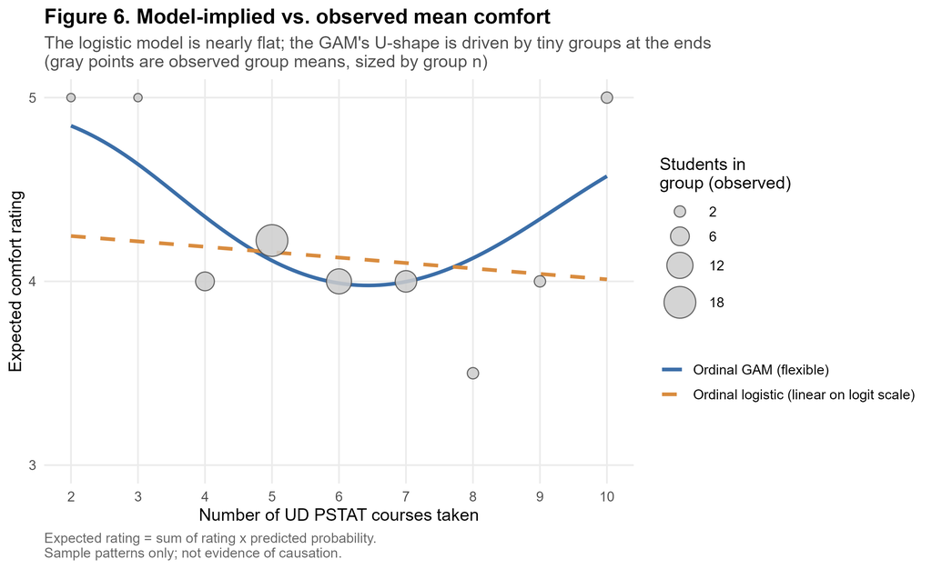

Figure 6. Model-implied vs. observed mean comfort.

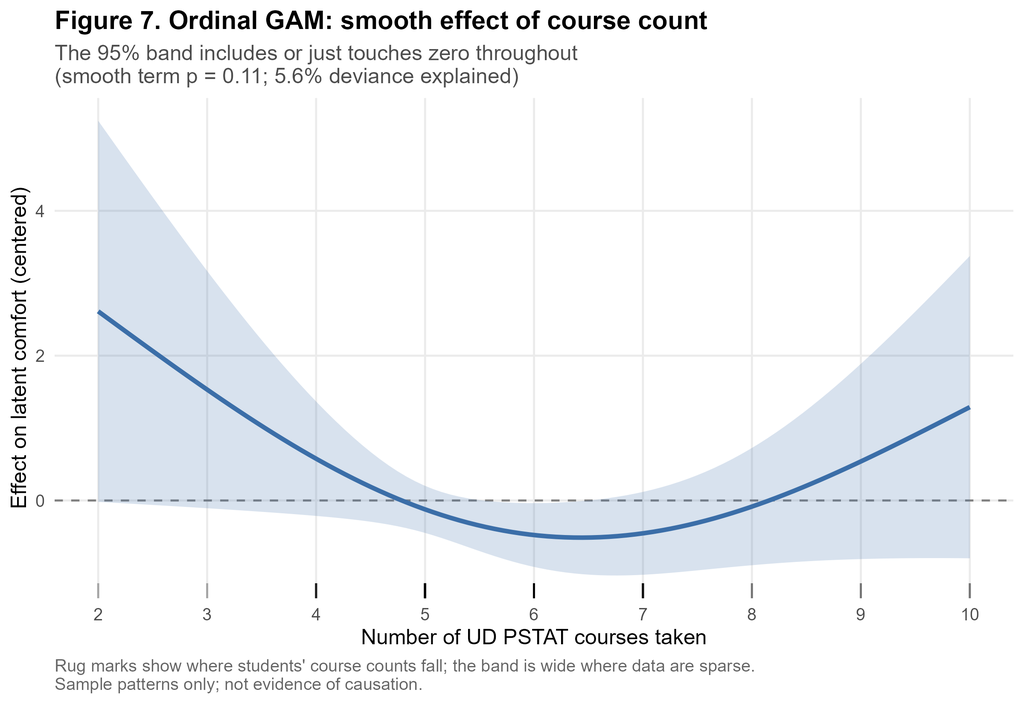

Figure 7. Ordinal GAM: smooth effect of course count.

**Spearman correlation.** The rank correlation is -0.11 (p = 0.45), which is close to zero and not statistically distinguishable from it (Figure 8). Because Spearman only looks at the ordering of values, it is a useful check that the null result does not depend on assuming equal spacing between rating categories.

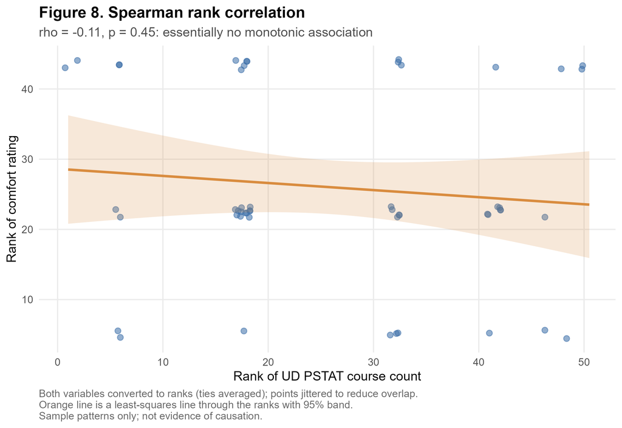

Figure 8. Spearman rank correlation.

## Interpretation

All three methods point the same way: **we do not see any statistically significant evidence that students who have taken more Upper Division PSTAT courses report different comfort with statistics than students who have taken fewer, at least in this sample.** The descriptive figures and the models agree, which makes the conclusion more convincing than any single test would on its own.

There are two points to be highlighted while we did this study:

1. **A non-significant result is not proof of no relationship.** With 51 students, mostly in a narrow range of course counts, the analysis has limited power. The confidence bands in Figures 5 and 7 are wide, so a modest real association could be present and still go undetected here.
2. **The apparent bumps and dips in the data are not trustworthy.** The high means at 2, 3 and 10 courses and the low mean at 8 courses each come from one or two students. The GAM’s U-shape inherits this noise. We recommend not describing these as a pattern in any write-up.

One useful way to describe the finding: most students in this sample, regardless of how many Upper-Div PSTAT courses they have taken, report being fairly comfortable with statistics (a 4 on a 5-point scale is typical).

## Our Limitations

- **Small sample and small groups.** Five of nine course-count groups have fewer than 5 students, and the estimates for them are very unstable.
- **Restricted range of the outcome.** Everyone rated comfort 3, 4 or 5. A ceiling effect like this compresses differences and makes associations harder to detect. It also means we cannot say anything about students with low comfort, who may be missing from the sample altogether.
- **Self-reported, ordinal outcome.** Comfort is a subjective rating, and “4” may mean different things to different students. Mean comfort assumes equal spacing between categories, which is why we also looked at full distributions, an ordinal model and a rank-based test.
- **Cross-sectional and observational.** We see one snapshot of each student. We cannot tell whether comfort changes as students take courses, or whether more comfortable students choose to take more courses. Other factors, such as major, year in school, prior background or course performance, are not accounted for.
- **Sample representativeness.** The analysis describes this sample only. If students who responded differ from those who did not, the results may not generalize.
- **Multiple analyses.** We looked at the question in several ways. Since none produced a significant result, this is less of a concern here, but it would matter if one analysis had stood out.

## Conclusion

In the sample, the number of upper-division PSTAT courses taken is not meaningfully associated with self-reported statistics comfort. Mean comfort is steady around 4 across the groups with enough students, and neither a linear ordinal model, a flexible GAM nor a rank correlation detects a relationship. These findings describe patterns in this sample only: they do not establish statistical significance in a broader population or show that taking more courses causes greater (or lesser) comfort.

A larger sample, especially one that includes more students with fewer or more courses and more students with lower comfort, would be needed to tell whether a small association exists.